October 2022

# Segregated by Design? The Effect of Street Network Topological Structure on the Measurement of Urban Segregation

Elijah Knaap

*San Diego State University*

Sergio Rey

*San Diego State University*

# Introduction

An exceedingly common abstraction in applied spatial analysis is the use of euclidean distance as a proxy measure for geographic proximity (which is, itself, often a proxy for the frequency of social interaction). It’s the geographic equivalent of [the spherical cow](https://en.wikipedia.org/wiki/Spherical_cow), save that scientists of many different disciplines often fail to realize how simplified it is. While, in general, simple proximity is a reasonable heuristic for understanding Tobler’s Law (Tobler, 1970), the behavioral realities of movement and social interaction in complex urban environments often require a more thoughtful model.

this project examines the relationship between pedestrian network characteristics and the measurement of metropolitan segregation. It examines three questions:

1. How large is the difference between euclidean-based and network-based measures of spatial segregation?
   - how often
   - where?
2. Are the differences between euclidean and network measures significantly different from random realizations of the same data?
   - how often
   - where
3. what characteristics of the pedestrian network explain the observed difference in measurement?

*really* quick overview of normative concepts of community and urban design… Daniel Burnham, Le Corbusier, Ebenezeer Howard, James Rouse, and… Emily Talen

how do we represent space in social science research?

classics: - sociology uses groups. Neighborhoods or cities are discrete containers that condition social behaviors (Park, Burgess, McKenzie) - econ and regional science use distance from the city center - ultimately about transport of goods (von thunen was based on an *agricultural economy* and moving crops from the ag hinterlands into the marketplace where people actually lived). - Transport connectivity is implicit, but models are high-level in the 1950s, and the abstraction works conceptually. Neither the theory or computational power exist yet to examine the role of better measurements of $W_{ij}$

recents: - GIS, geography, and spatial econometrics concepts of spatial weights - multiscale and/or bespoke neighborhoods in geography and sociology (HIPP & BOESSEN (2013), van Ham, ) - street networks in empirical work - grannis shows social interactions are more frequent inside T-communities defined by street networks - Roberto uses street networks to measure segregation in a small-scale case study.

Now we have both the tools and the logic to test these assumptions and understand the role of abstractions such as euclidean distance-based measures in our assessment of critical social processes such as residential segregation. Fast graph algorithms allow us to construct more realistic concepts of spatial weights matrices, and computational statistics allow us to construct and test realistic null hypotheses about the allocation of urban population groups. Here, we examine the role of street network topology in the appropriate measurement of urban segregation. Our goals are twofold. First, we aim to understand the implications of simple Euclidean distance- based abstractions when conducting formal spatial analyses; that is, do we find substantive differences in results when more realistic concepts of spatial relationships (e.g. network connectivity) are considered? Second, we aim to explore the elements of urban design (particularly the street network configuration) in widening the gap between analytical abstraction and empirical reality. More simply, we aim to understand whether certain elements of the street network are associated with a greater difference in measured segregation. With this knowledge, urban designers and planners can begin with more inclusive communities from the beginning.

# Urban Infrastructure and Social Interactions

Classically, space is treated as a discrete concept, by membership in a group (i.e. a school, classroom, neighborhood, or city), where any of these groupings is defined exogenously.

## The Role of Space in Segregation Measurement

### Making Space Explicit

Reardon & O’Sullivan (2004) Reardon et al. (2009) Wong (1997) Bailey (2012) Rey & Folch (2011) O’Sullivan & Wong (2007) Wong (2004) Dawkins (2004)

### Interrogating Spatial Scale

Lee et al. (2008) Reardon et al. (2008) Bézenac et al. (2022) Olteanu et al. (2019) Östh et al. (2015) Clark et al. (2015)

## Homogenous Communities and Urban Design

A long-recognized but understudied element of metropolitan segregation patterns is the role of transport networks, physical barriers, and other factors such as elevation or congestion that change travel behavior, and thus, the expected potential for social interaction in space. For example work in sociology has shown the importance of street network connectivity in fostering connected social networks inside small urban geographic zones (Grannis, 1998).

Grannis (2005) Roberto (2018)

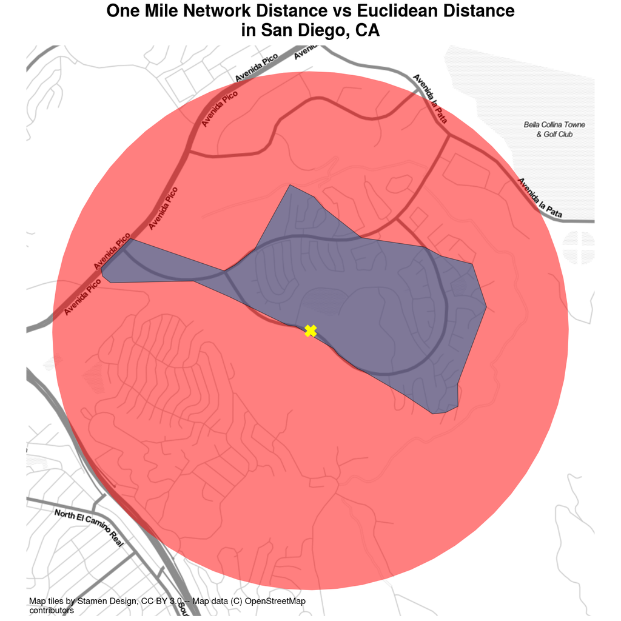

Figure 1: Network Distance vs Euclidean Distance

A depiction of the difference between network travel distance and “as the crow flies” distance is shown in Figure 1. The figure shows an origin marked with an X in the center, and two different polygons representing a one-mile travel distance using different methods. The small polygon depicts the total extent accessible from the origin point when traveling along the pedestrian network, whereas the larger polygon depicts the 1-mile buffer representing unconstrained travel. It is immediately apparent in the figure that network-constrained travel covers a much smaller footprint than euclidean distance in the depicted location. Furthermore, the pattern appears to be influenced strongly by the street network and urban design features that characterize the largely suburban region of the San Diego metro area. Instead of a regular grid that facilitates travel in all directions, the street network in Figure 1 includes several insular patterns, cul-de-sacs, and 3-way intersections that help channel traffic in certain directions rather than others. Furthermore, the fact that some subdivisions have only a single entrance makes clear how much further a person would need to travel to reach the homes in certain regions (versus how much easier they appear to be reached via the circular buffer).

# The Role of Network Distance in Segregation Measurement

We begin our analysis by computing two sets of segregation indices, adopting the spatial information theory statistic $\tilde{H}$ as our measure of segregation. As Reardon et al. (2008, p. 512) describe, “the index $\tilde{H}$ is a measure of how much less diverse individuals’ local environments are, on average, than is the total population of region,” and reaches its maximum of 1 only when “each individual’s local environment is monoracial.” Here, our goal is to test how sensitive the statistic is to different concepts of the “local environment,” with one concept adopting the simplified assumption of euclidean-based distance measurements, and the other requiring that distance be measured along a pedestrian transport network.

## Measuring Segregation in Space

Following Reardon & O’Sullivan (2004) we consider a spatial region $R$ populated by $M$ racial groups indexed by $m$, with $\tau$ and $\pi$ as population density and proportion, respectively. Here we diverge from the classical notation in the segregation literature and instead adopt conventions more common in spatial econometrics and geographic analysis. Doing so allows us to strengthen the connection between similar concepts in different disciplines as well as gain finer control over the definition of spatial relationships. Since many spatial segregation measures are implemented in GIS and spatial analysis software designed by geographers, clarifying this connection can help ease interdisciplinary adoption and conversation around spatial segregation measures.

Thus, we index locations within $R$ as $i$ and $j$, and we operationalize the concept of spatial relationships using a spatial weights matrix $W_{ij}$. By focusing on $W_{ij}$, we are forced “to specify [our] underlying assumptions about socio-spatial proximity,” following the call by Reardon & O’Sullivan (2004, p. 154) for analysis that “compares segregation levels based on different theoretical bases for defining spatial proximity.” Conceptually, the spatial weights matrix $W_{ij}$ is connectivity graph that defines the spatial relationship between nodes $i$ and $j$, and the values $w_{ij}$ encode the intensity of the edge $\bar{ij}$. Thus, the spatial weights matrix is a useful and flexible representation of the local neighborhood environment because it provides a generic data structure for encoding spatial relationships, where any link function ($\phi$, following the notation of Reardon & O’Sullivan (2004)) can be used to specify the proximity between units. Formally,

$$SL_i = \sum_j w_{ij} y_j \qquad{(2)}$$
In the spatial econometrics literature, it is common to exclude the diagonal elements from $W_{ij}$ to differentiate between focal effects and spatial spillovers in regression models, but when the diagonal is filled, then $SL_i$ becomes a consummate measure of the local environment at location $i$.

To compute the spatial multigroup information theory index $\tilde{H}$, we first calculate local spatially-weighted population proportions as

$$\tilde{\pi}_{im} = \frac{SL_{im}}{\sum^M{SL_{im}}} \qquad{(3)}$$
The density at location $i$ is

$$\tilde{\tau_i} = \frac{\sum^M_{m=1}{SL_{im}}}{\sum^M_{m=1}\sum^I_{i=1}{SL_{im}}} \qquad{(4)}$$
The entropy of the local environment at each location $\tilde{E}_i$ is

$$\tilde{E}_i = -\sum^M_{m=1}(\tilde{\pi}_{im})\log_M(\tilde{\pi}_{im}) \qquad{(5)}$$
where $M$ indicates the number of groups in the population. Finally,

$$\tilde{H} = 1-\frac{1}{TE} \sum^I \tilde{\tau_i}\tilde{E}_i \qquad{(6)}$$
where $\tilde{H}$ is the spatial information theory index defined by Reardon & O’Sullivan (2004). We perform all calculations using the open-source Python package `segregation` (Cortes et al., 2020), distributed as part of the Python Spatial Analysis Library (PySAL) (Rey et al., 2021)

## Assessing Difference Between Distance Metrics

To understand the implications of different parameterizations of space, we use data blockgroup-level from the US Census American Community Survey (ACS) 5-year sample (2013-2017) with four mutually-exclusive racial groups (non-Hispanic white, non-Hispanic Black, Hispanic, and Asian). Our sample contains data for 380 metropolitan Core Based Statistical Areas (CBSAs) in the United States. Blockgroups are the smallest geographic unit for which racial and ethnic data are available in the ACS. To compute euclidean-based spatial segregation measures, our distances are measured between blockgroup centroids; to compute network-based spatial segregation measures, we first attach the blockgroup centroids to the nearest intersection in the travel network, then compute the shortest network-based path between each pair of observations using the Python package `pandana` (Foti et al., 2012).

### Constructing Comparable Indices

In each metropolitan region, we proceed by creating two different spatial weights matrices by varying the way distance is measured between observations. In both matrices, the proximity-weighting function $\phi$ is a simple linear decay (triangular kernel) encoding a spatial weight that decreases with distance up to a threshold of two kilometers (outside of which observations no longer have an effect):

$$\phi=
\begin{dcases}
1- \left( \frac{d_{ij}}{2000} \right),& \text{if } d_{ij}\leq 2000\\
0, & \text{otherwise}
\end{dcases}
\qquad{(7)}$$

Between the two $W$ matrices, however, we vary the input distance matrix $D$, between two concepts, euclidean distance and network distance (where network distance is defined as the shortest path along the pedestrian transportation network), $W_{net}$, and $W_{euc}$. In both matrices the diagonal is set to one, indicating that there is no spatial discount for the value located at observation $i$. Using these weights matrices to construct local environments for each metropolitan region yields two segregation measures $\tilde{H}_{net}$, $\tilde{H}_{euc}$ and, implicitly, a difference between the two ($\tilde{H}_{diff}$).

### Inferential Framework

We assess the importance of considering network distance in segregation measurement by adopting the inferential framework outlined in Cortes et al. (2020). The approach leverages a computational approach to statistical inference using random labelling to compare the observed difference between the two segregation measures (network versus euclidean) to a distribution of differences generated from the same data. More specifically, the measures $\tilde{H}_{net}$, $\tilde{H}_{euc}$ and $\tilde{H}_{diff}$ are computed and recorded for each metro region. As a result of this process, two “spatialized” versions of the metropolitan demographic composition are created, with one dataset representing euclidean distances and the other representing network-based distances.

We then create two synthetic datasets by pooling the input units from both original datasets and reassigning them at random. Once all units have been assigned to a group, the segregation measures are re-computed and their difference taken. This process is repeated 10,000 iterations. By comparing the observed difference between the two segregation measures against a distribution of differences generated via synthetic datasets, we can develop pseudo p-values based on a standard T-test. Our test in this case measures the empirical likelihood of obtaining the observed difference at random under the null hypothesis that no difference exists between the two measurements.

## Network Distance is an Important Consideration

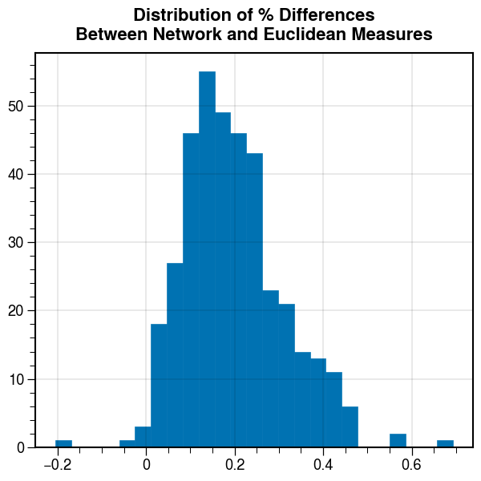

Figure 2: Histogram of % Differences in Segregation Measures

The distribution of differences is approximately normal. While the absolute difference between the two segregation measures in each CBSA can appear small, the relative difference is often reasonably large, with the network-based segregation measure approximately 20% higher than the euclidean-based measure on average. The largest relative difference gets as high as 69% (Carson City, NV).

# Network Characteristics and Segregation Differences

## Metropolitan Travel Infrastructure as a Network Graph

The travel infrastructure in a metropolitan region serves as its skeleton for both urban development and social interactions. For decades, scholars have worked to quantify the aspects of urban form that help explain behaviors such as travel mode choice Ewing & Cervero (2010). A recent evolution of this work is the conception of a travel network as a formal graph structure (Boeing, 2018a, 2018b; Fleischmann, 2018; Fleischmann et al., 2021), and a set of software tools that facilitate its analysis (Boeing, 2016; Fleischmann, 2019).

## Measuring Graph Structure

We use OSMNx and Momepy to create measures of the pedestrian travel network collected from OpenStreetMap.

## Graph Topology and Segregation Differences

# Discussion

There are two additional parameters worth exploring: the distance-decay function $\phi$, and the distance threshold that defines the extend of the local environment

# Conclusion

In the segregation literature, the importance of *space* has long been recognized, but a full grasp of its implications still eludes researchers. In this paper, we show that when considering the role of transportation infrastructure in segregation measurement, we obtain substantially different results than classic spatial approaches that adopt euclidean measurements.

In future work, this research could be extended in several directions

One promising direction is the consideration of alternative impedance measures when calculating shortest-path distances along the travel network. In the present study, we assume a constant rate of travel consistent with the average walking pace, and that impedance is reflected by graph distance alone. Alternative constructs could include elevation along with distance to get a more complete measure of the effort required to traverse by foot or bicycle. Similarly, the travel network could also be extended to include public transportation or (potentially congested) automobile travel. These considerations would require extensive additional data, which may limit the capacity for cross-sectional comparisons, but would also provide insight into alternative concepts of space and distance.

Another important avenue for further work is the blending of multiple graphs for a more complete understanding of multi-contextual segregation. For example children who live in a given neighborhood are simultaneously embedded in local neighborhood contexts, school catchment boundaries, and other local institutions such as religious and community organizations. Each of these contexts have partially-overlapping, occasionally nested, and often imperfectly-defined geographic boundaries, a full synthesis of which requires the development of new methods that integrate across these contexts (Galster, 2001; Galster, 2019). As one example, Wolf (2021) provides a technique for blending multiple graphs together, one spatial and one aspatial, and similar methods could be possibly used to integrate multiple contexts. Work along these lines would also help address the call by Reardon & O’Sullivan (2004, p. 156) for metrics that help understand bridges across social networks

# References

Bailey, N. (2012). How Spatial Segregation Changes over Time: Sorting Out the Sorting Processes. *Environment and Planning A: Economy and Space*, *44*(3), 705–722. https://doi.org/10.1068/a44330

Bézenac, C., Clark, W. A. V., Olteanu, M., & Randon-Furling, J. (2022). Measuring and Visualizing Patterns of Ethnic Concentration: The Role of Distortion Coefficients. *Geographical Analysis*, *54*(1), 173–196. https://doi.org/10.1111/gean.12271

Boeing, G. (2016). OSMnx: New Methods for Acquiring, Constructing, Analyzing, and Visualizing Complex Street Networks. *Computers, Environment and Urban Systems*, *65*, 126–139. https://doi.org/10.1016/j.compenvurbsys.2017.05.004

Boeing, G. (2018a). Planarity and street network representation in urban form analysis. *Environment and Planning B: Urban Analytics and City Science*, 239980831880294. https://doi.org/10.1177/2399808318802941

Boeing, G. (2018b). The Morphology and Circuity of Walkable and Drivable Street Networks. *SSRN Electronic Journal*. https://doi.org/10.2139/ssrn.3119939

Clark, W. A. V., Anderson, E., Östh, J., & Malmberg, B. (2015). A Multiscalar Analysis of Neighborhood Composition in Los Angeles, 2000: A Location-Based Approach to Segregation and Diversity. *Annals of the Association of American Geographers*, *105*(6), 1260–1284. https://doi.org/10.1080/00045608.2015.1072790

Clifton, K., Ewing, R., Knaap, G.-J., & Song, Y. (2008). Quantitative analysis of urban form: A multidisciplinary review. *Journal of Urbanism: International Research on Placemaking and Urban Sustainability*, *1*(1), 17–45. https://doi.org/10.1080/17549170801903496

Cortes, R. X., Rey, S., Knaap, E., & Wolf, L. J. (2020). An open-source framework for non-spatial and spatial segregation measures: The PySAL segregation module. *Journal of Computational Social Science*, *3*(1), 135–166. https://doi.org/10.1007/s42001-019-00059-3

Crane, R. (2000). The Influence of Urban Form on Travel: An Interpretive Review. *Journal of Planning Literature*, *15*(1), 3–23. https://doi.org/10.1177/08854120022092890

Dawkins, C. J. (2004). Measuring the {}Spatial{} {}Pattern{} of {}Residential{} {}Segregation{}. *Urban Studies*, *41*(4), 833. https://doi.org/10.1080/0042098042000194133

Ewing, R., & Cervero, R. (2010). Travel and the Built Environment. *Journal of the American Planning Association*, *76*(3), 265–294. https://doi.org/10.1080/01944361003766766

Ewing, R., & Handy, S. (2009). Measuring the Unmeasurable: Urban Design Qualities Related to Walkability. *Journal of Urban Design*, *14*(1), 65–84. https://doi.org/10.1080/13574800802451155

Fleischmann, M. (2018). Measuring Urban Form: Overcoming Terminological Inconsistencies for a Quantitative and Comprehensive Morphologic Analysis of Cities. *Environment and Planning B: Urban Analytics and City Science 1*, *0*(0), 1–19. https://doi.org/10.1177/2399808320910444

Fleischmann, M. (2019). Momepy: Urban Morphology Measuring Toolkit. *Journal of Open Source Software*, *4*(43), 1807. https://doi.org/10.21105/joss.01807

Fleischmann, M., Feliciotti, A., Romice, O., & Porta, S. (2021). Methodological foundation of a numerical taxonomy of urban form. *Environment and Planning B: Urban Analytics and City Science*, *0*(0), 239980832110598. https://doi.org/10.1177/23998083211059835

Foti, F., Waddell, P., & Luxen, D. (2012). A Generalized Computational Framework for Accessibility : From the Pedestrian to the Metropolitan Scale. *4th Transportation Research Board Conference on Innovations in Travel Modeling (ITM)*, 1–14.

Galster, G. (2001). On the nature of neighbourhood. *Urban Studies*, *38*(12), 2111. https://doi.org/10.1080/00420980120087072

Galster, G. C. (2019). *Making our neighborhoods, making our selves*. University of Chicago Press.

Grannis, R. (1998). The Importance of Trivial Streets: Residential Streets and Residential Segregation. *American Journal of Sociology*, *103*(6), 1530–1564. https://doi.org/10.1086/231400

Grannis, R. (2005). T-Communities: Pedestrian Street Networks and Residential Segregation in Chicago, Los Angeles, and New York. *City and Community*, *4*(3), 295–321. https://doi.org/10.1111/j.1540-6040.2005.00118.x

HIPP, J. R., & BOESSEN, A. (2013). EGOHOODS AS WAVES WASHING ACROSS THE CITY: A NEW MEASURE OF “NEIGHBORHOODS.” *Criminology*, *51*(2), 287–327. https://doi.org/10.1111/1745-9125.12006

Lee, B. A., Reardon, S. F., Firebaugh, G., Farrell, C. R., Matthews, S. A., & O’Sullivan, D. (2008). Beyond the Census Tract: Patterns and Determinants of Racial Segregation at Multiple Geographic Scales. *American Sociological Review*, *73*(5), 766–791. https://doi.org/10.1177/000312240807300504

O’Sullivan, D., & Wong, D. W. S. (2007). A Surface-Based Approach to Measuring Spatial Segregation. *Geographical Analysis*, *39*(2), 147–168. https://doi.org/10.1111/j.1538-4632.2007.00699.x

Olteanu, M., Randon-Furling, J., & Clark, W. A. V. (2019). Segregation through the multiscalar lens. *Proceedings of the National Academy of Sciences*, *116*(25), 12250–12254. https://doi.org/10.1073/pnas.1900192116

Östh, J., Clark, W. A. V., & Malmberg, B. (2015). Measuring the Scale of Segregation Using k -Nearest Neighbor Aggregates. *Geographical Analysis*, *47*(1), 34–49. https://doi.org/10.1111/gean.12053

Reardon, S. F., Farrell, C. R., Matthews, S. A., O’Sullivan, D., Bischoff, K., & Firebaugh, G. (2009). Race and space in the 1990s: Changes in the geographic scale of racial residential segregation, 1990. *Social Science Research*, *38*(1), 55–70. https://doi.org/10.1016/j.ssresearch.2008.10.002

Reardon, S. F., Matthews, S. A., O’Sullivan, D., Lee, B. A., Firebaugh, G., Farrell, C. R., & Bischoff, K. (2008). The geographic scale of Metropolitan racial segregation. *Demography*, *45*(3), 489–514. https://doi.org/10.1353/dem.0.0019

Reardon, S. F., & O’Sullivan, D. (2004). Measures of Spatial Segregation. *Sociological Methodology*, *34*(1), 121–162. https://doi.org/10.1111/j.0081-1750.2004.00150.x

Rey, S. J., Anselin, L., Amaral, P., Arribas-Bel, D., Cortes, R. X., Gaboardi, J. D., Kang, W., Knaap, E., Li, Z., Lumnitz, S., Oshan, T. M., Shao, H., & Wolf, L. J. (2021). The PySAL Ecosystem: Philosophy and Implementation. *Geographical Analysis*, gean.12276. https://doi.org/10.1111/gean.12276

Rey, S. J., & Folch, D. C. (2011). Impact of spatial effects on income segregation indices. *Computers, Environment and Urban Systems*, *35*(6), 431–441. https://doi.org/10.1016/j.compenvurbsys.2011.07.008

Roberto, E. (2018). The Spatial Proximity and Connectivity Method for Measuring and Analyzing Residential Segregation. *Sociological Methodology*, *48*(1), 008117501879687. https://doi.org/10.1177/0081175018796871

Tobler, W. R. (1970). A Computer Movie Simulating Urban Growth in the Detroit Region. *Economic Geography*, *46*(May), 234. https://doi.org/10.2307/143141

Wolf, L. J. (2021). Spatiallyencouraged spectral clustering: A technique for blending map typologies and regionalization. *International Journal of Geographical Information Science*, *35*(11), 2356–2373. https://doi.org/10.1080/13658816.2021.1934475

Wong, D. S. W. S. (1997). Spatial dependency of segregation indices. *Canadian Geographer*, *41*(2), 128–136. https://doi.org/10.1111/j.1541-0064.1997.tb01153.x

Wong, D. W. S. (2004). Comparing Traditional and Spatial Segregation Measures: A Spatial Scale Perspective. *Urban Geography*, *25*(1), 66–82. https://doi.org/10.2747/0272-3638.25.1.66

[^1]: For each CBSA in our sample, our euclidean distances are based on UTM coordinate systems, with each region’s data projected into its appropriate UTM zone.